# C-reactive protein in adults with and without rheumatoid arthritis

Dataset 10: Cardiovascular risk and carotid artery thickness in rheumatoid arthritis

RSR feasibility analysis

2026-08-03

# Introduction

The source study recruited adults with rheumatoid arthritis (RA) and healthy controls without RA in the Netherlands, and put every participant through the same physical examination and fasting laboratory panel, including C-reactive protein (Hollan and colleagues, *PLOS ONE*, 2015). This teaching extract holds 470 participants, 307 with RA and 163 controls. C-reactive protein is the standard clinical marker of systemic inflammation: it is the laboratory value used to judge whether rheumatoid disease is active, and independently of that it is one of the best-established biomarkers of cardiovascular risk, so the question of what raises it in a mixed RA and non-RA population sits at the junction of the two literatures.

**Aim.** Among these Dutch adults, we examined which of RA status, age, sex, adiposity, blood pressure, smoking, lipid-lowering and antihypertensive treatment, the fasting lipid panel and glucose are independently associated with C-reactive protein, mutually adjusting for the others.

This is a *Purpose 3* analysis: several predictors are of interest and the question is which remain associated with the outcome after mutual adjustment.

# Methods

**Data source.** A cross-sectional case-control comparison conducted in the Netherlands and published in *PLOS ONE* in 2015. Cases were adults with established rheumatoid arthritis; controls were adults without RA recruited from the same setting. This extract contains 470 participants and 25 variables. Ages run from 20 to 70 years.

**Variables.** The outcome is `crp`, C-reactive protein, recorded as whole numbers running from 1 to 71 with a median of 2; the units are not stated in the deposit but the values are consistent with mg/L. **It is modelled on the natural-log scale** for the reasons set out below, so every coefficient is reported as a multiplicative ratio of geometric mean CRP. Predictors are rheumatoid arthritis status (reference Control), age in years, sex (reference Female), BMI in kg/m2, systolic blood pressure in mmHg, current smoking (reference No), statin use (reference No), antihypertensive use (reference No), total cholesterol, HDL cholesterol and triglycerides in mmol/L, and fasting glucose in mmol/L.

**`crp` is removed from the predictor set.** The catalogue’s suggested predictor list for this dataset includes `crp`, because that list is shared across all three outcomes. Regressing CRP on itself is circular, so it is dropped here. 12 predictors remain.

**Variables excluded on structural grounds.** `ldl_cholesterol` is not independently measured in this file: against the Friedewald formula (`total - HDL - triglycerides/2.2`) it correlates 0.9987, so including it alongside all three of its inputs creates a near-exact linear dependency and inflates the lipid variance inflation factors into the hundreds. `waist_cm` duplicates `bmi` (r 0.81) and `diastolic_bp` duplicates `systolic_bp` (r 0.67); one of each pair is kept. `apo_a` and `apo_b` are alternative measurements of the HDL and total-cholesterol fractions (r 0.55 and 0.83). `weight_kg` and `height_cm` are excluded because `bmi` is exactly `weight_kg/(height_cm/100)^2`. `prednisone` is excluded because it is an anti-inflammatory drug given almost exclusively to the RA group (1 of 39 users are controls) and would sit directly on the pathway between RA and CRP.

**Parameter budget.** 455 complete cases for 12 parameters, all single degree-of-freedom terms, is 38 observations per parameter - comfortably inside the 10-15 per parameter a linear model needs. The binding constraint on this model is collinearity and interpretability, not sample size.

**Statistical analysis.** `lm()`, justified because the outcome is a continuous laboratory measurement. Raw CRP is severely right-skewed (skewness 5.1; the largest value, 71, is 36 times the median), so a model on the raw scale would be dominated by a handful of participants with an acute inflammatory episode. Taking natural logs reduces the skewness to 0.9 and, as reported in the Diagnostics, roughly halves the residual skewness and doubles the explained variance, so **the analysis is carried out on log CRP**. We fitted a univariable model for each predictor first, then a single multivariable model containing all 12. Predictors were chosen in advance on subject-matter grounds, not by significance. Significance threshold 0.05; estimates are reported with 95% confidence intervals and, for readability, exponentiated to ratios of geometric mean CRP. Assumptions were checked with `performance::check_model()` and `check_collinearity()`, and because non-constant variance was flagged even after transformation we additionally report HC3 heteroscedasticity-consistent standard errors. Analysis used R version 4.6.0 (2026-04-24) with tidyverse, gtsummary and performance.

**Data integrity.** The catalogue notes that in the original Zenodo deposit `sex` was coded 0 = woman / 1 = man and the height column mixed metres and centimetres. Both are corrected here: `sex` ships as the strings female and male and `height_cm` runs from 145 to 206 cm with 0 values below 3. One defect remains: row `id = "control_row1"` is entirely blank apart from `id`, `has_ra` and `hypertension_or_hyperchol`.

**Missing data.** Complete-case analysis: 455 of 470 rows were analysed (15 dropped, 3.2%). The outcome is 98.9% complete (5 missing); the rest of the attrition is spread thinly across the predictors, the largest contributors being `statins` (6 missing), `antihypertensives` (4) and `current_smoker` (4). Only 406 of 470 rows are complete on *every* column in the file.

# Results

## Sample characteristics

**Table 1. Sample characteristics of the analytic sample, by rheumatoid arthritis status.**

| **Characteristic** | **N** | **Control** N = 158<sup>1</sup> | **RA** N = 297<sup>1</sup> |
| --- | --- | --- | --- |
| CRP (mg/L) | 455 | 1.0 (1.0, 3.0) | 3.0 (1.0, 6.0) |
| Age (years) | 455 | 53 (44, 61) | 55 (46, 62) |
| Sex | 455 |  |  |
| Female |  | 96 (61%) | 202 (68%) |
| Male |  | 62 (39%) | 95 (32%) |
| BMI (kg/m2) | 455 | 25.2 (22.4, 27.3) | 26.0 (23.5, 29.0) |
| Systolic BP (mmHg) | 455 | 124 (116, 134) | 130 (120, 140) |
| Current smoker | 455 | 24 (15%) | 60 (20%) |
| Taking a statin | 455 | 22 (14%) | 13 (4.4%) |
| Taking antihypertensives | 455 | 30 (19%) | 54 (18%) |
| Total cholesterol (mmol/L) | 455 | 5.40 (4.70, 6.00) | 5.40 (4.60, 6.00) |
| HDL cholesterol (mmol/L) | 455 | 1.50 (1.20, 1.80) | 1.50 (1.20, 1.70) |
| Triglycerides (mmol/L) | 455 | 1.22 (0.82, 1.66) | 1.04 (0.74, 1.49) |
| Fasting glucose (mmol/L) | 455 | 5.20 (4.80, 5.70) | 5.40 (5.10, 5.80) |

<sup>1</sup> Median (Q1, Q3); n (%)

The RA group has markedly higher CRP (median 3, interquartile range 1 to 6) than the controls (median 1, interquartile range 1 to 3), which is exactly what an inflammatory arthritis should produce. The RA arm is also older and more female, and differs modestly in BMI and blood pressure, but the two groups’ lipid profiles are close.

## Outcome distribution and the log transformation

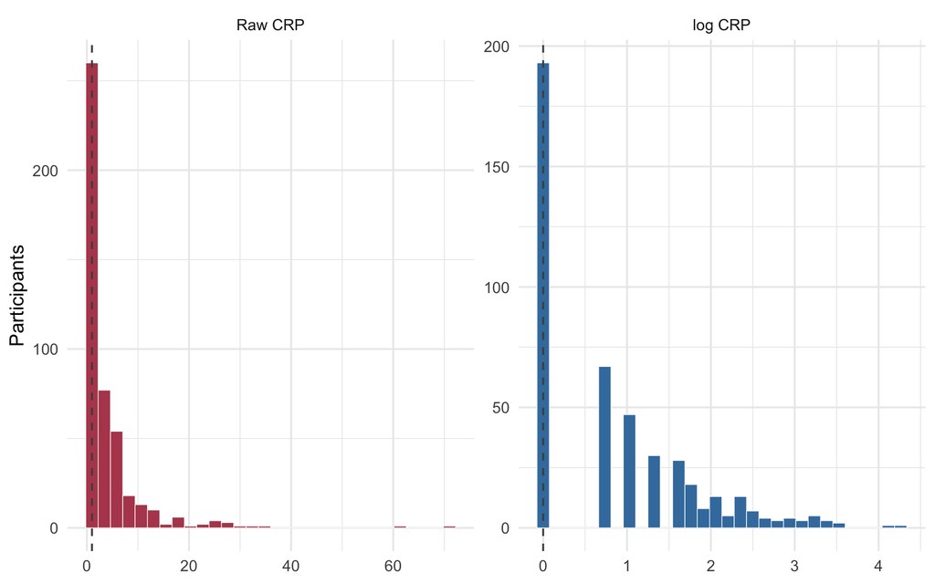

Figure 1. Distribution of C-reactive protein on the raw scale (left) and after log transformation (right). The dashed line marks the lower reporting limit of 1.

Raw CRP is extremely right-skewed (skewness 5.1), with a long thin tail out to 71; logging pulls the skewness down to 0.9. The transformation does not fix everything, though: 42% of the analytic sample sits exactly at the lower reporting limit of 1 (log 0), the spike at the left of the right-hand panel. That point mass is a censoring artefact - these participants’ true CRP is “below the assay’s reporting threshold”, not “exactly 1” - and no transformation can remove it.

## Exploratory figure

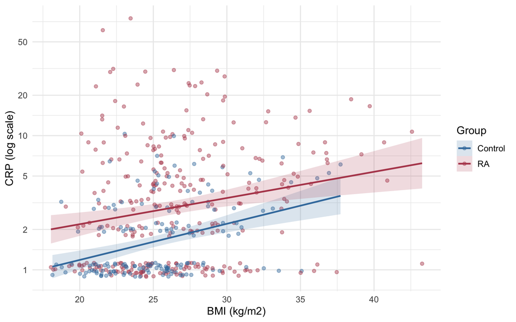

Figure 2. C-reactive protein (log scale) against BMI, separately for participants with rheumatoid arthritis and controls, with linear smoothers and 95% confidence bands.

## Univariable models

| **Characteristic** | **N** | **Ratio** | **95% CI** | **p-value** |
| --- | --- | --- | --- | --- |
| Age (years) | 455 | 1.003 | 0.995, 1.011 | 0.5 |
| Sex | 455 |  |  |  |
| Female |  | — | — |  |
| Male |  | 0.929 | 0.773, 1.117 | 0.4 |
| Rheumatoid arthritis | 455 |  |  |  |
| Control |  | — | — |  |
| RA |  | 1.780 | 1.492, 2.123 | <0.001 |
| BMI (kg/m2) | 455 | 1.059 | 1.038, 1.079 | <0.001 |
| Systolic BP (mmHg) | 455 | 1.010 | 1.005, 1.015 | <0.001 |
| Current smoker | 455 |  |  |  |
| No |  | — | — |  |
| Yes |  | 1.078 | 0.860, 1.351 | 0.5 |
| Taking a statin | 455 |  |  |  |
| No |  | — | — |  |
| Yes |  | 0.798 | 0.575, 1.108 | 0.2 |
| Taking antihypertensives | 455 |  |  |  |
| No |  | — | — |  |
| Yes |  | 1.084 | 0.865, 1.359 | 0.5 |
| Total cholesterol (mmol/L) | 455 | 0.911 | 0.841, 0.986 | 0.021 |
| HDL cholesterol (mmol/L) | 455 | 0.701 | 0.583, 0.842 | <0.001 |
| Triglycerides (mmol/L) | 455 | 1.123 | 0.991, 1.273 | 0.069 |
| Fasting glucose (mmol/L) | 455 | 1.212 | 1.073, 1.369 | 0.002 |

Abbreviation: CI = Confidence Interval

Because the outcome is logged, each coefficient below is a **multiplicative ratio of geometric mean CRP**; a ratio of 1 means no association. Rheumatoid arthritis is by far the strongest crude predictor: RA cases have 1.780 (95% CI 1.492 to 2.123) times the geometric mean CRP of controls (p <0.001), i.e. roughly a 78% higher CRP. Adiposity follows - each additional kg/m2 of BMI is associated with a ratio of 1.059 (95% CI 1.038 to 1.079) (p <0.001), which compounds to about 1.33-fold across 5 kg/m2 - then HDL cholesterol, where each additional mmol/L is associated with a ratio of 0.701 (95% CI 0.583 to 0.842) (p <0.001), fasting glucose (1.212 (95% CI 1.073 to 1.369) per mmol/L, p = 0.002), systolic pressure (1.010 (95% CI 1.005 to 1.015) per mmHg, p <0.001) and total cholesterol (0.911 (95% CI 0.841 to 0.986) per mmol/L, p = 0.021). Age (p = 0.497), sex (p = 0.435), current smoking (p = 0.515), statin use (p = 0.178), antihypertensive use (p = 0.483) and triglycerides (p = 0.069) show no crude association.

## Why adjustment is needed

**BMI** is the clearest confounder in this dataset, and it works on the lipid associations. Adipose tissue secretes interleukin-6, which drives hepatic CRP production, so BMI is a direct cause of higher CRP (a ratio of 1.059 (95% CI 1.038 to 1.079) crude); it is also strongly related to the lipid panel, being correlated -0.27 with HDL cholesterol and 0.23 with triglycerides. The crude “low HDL means high CRP” association is therefore partly an adiposity association wearing a lipid label: adding BMI alone moves the HDL ratio from 0.701 (95% CI 0.583 to 0.842) to 0.795. The same argument applies to fasting glucose, which is correlated 0.23 with BMI.

**RA status** is the second variable that must be handled explicitly, because it is associated with almost everything else here. RA cases have higher CRP by construction of the disease, and they also have higher BMI (mean 26.6 versus 25.4 kg/m2), higher blood pressure, and a much lower rate of statin use (4.4% versus 13.9% of controls). Any crude coefficient in this file is therefore partly a case-control contrast. **Statin use** deserves its own warning: it is confounded by indication, and here also confounded by group membership, since it is largely the controls who are on statins. Mutual adjustment lets each ratio be read as a comparison between participants of the same RA status, age, sex, body mass, blood pressure, treatment and lipid profile.

## Multivariable model

| **Characteristic** | **Ratio** | **95% CI** | **p-value** |
| --- | --- | --- | --- |
| Age (years) | 1.002 | 0.994, 1.011 | 0.6 |
| Sex |  |  |  |
| Female | — | — |  |
| Male | 0.789 | 0.653, 0.952 | 0.014 |
| Rheumatoid arthritis |  |  |  |
| Control | — | — |  |
| RA | 1.538 | 1.285, 1.841 | <0.001 |
| BMI (kg/m2) | 1.036 | 1.015, 1.057 | <0.001 |
| Systolic BP (mmHg) | 1.007 | 1.002, 1.012 | 0.011 |
| Current smoker |  |  |  |
| No | — | — |  |
| Yes | 1.054 | 0.855, 1.300 | 0.6 |
| Taking a statin |  |  |  |
| No | — | — |  |
| Yes | 0.686 | 0.493, 0.956 | 0.026 |
| Taking antihypertensives |  |  |  |
| No | — | — |  |
| Yes | 0.878 | 0.701, 1.100 | 0.3 |
| Total cholesterol (mmol/L) | 0.857 | 0.782, 0.938 | <0.001 |
| HDL cholesterol (mmol/L) | 0.845 | 0.678, 1.053 | 0.13 |
| Triglycerides (mmol/L) | 1.149 | 0.999, 1.322 | 0.052 |
| Fasting glucose (mmol/L) | 1.102 | 0.975, 1.246 | 0.12 |

Abbreviation: CI = Confidence Interval

**Model fit: multivariable linear model for log CRP**

| Statistic | Value |
| --- | --- |
| Complete-case N | 455 |
| Parameters (excl. intercept) | 12 |
| Observations per parameter | 37.9 |
| R-squared | 0.192 |
| Adjusted R-squared | 0.170 |
| Residual SE (log scale) | 0.866 |
| R-squared, same model on untransformed CRP | 0.098 |

The model explains 19.2% of the variance in log CRP (adjusted R-squared 0.170). The same twelve predictors applied to untransformed CRP explain only 9.8%, so the transformation roughly doubles the explained variance as well as fixing the skew.

Six predictors survive adjustment. The exposure of primary interest holds up: among participants of the same age, sex, body mass, blood pressure, treatment and lipid profile, RA cases have 1.538 (95% CI 1.285 to 1.841) times the geometric mean CRP of controls (p <0.001). Among participants alike on everything else, each additional kg/m2 of BMI is associated with a ratio of 1.036 (95% CI 1.015 to 1.057) (p <0.001), or about 1.19-fold per 5 kg/m2; each mmol/L of total cholesterol with a ratio of 0.857 (95% CI 0.782 to 0.938) (p <0.001); each mmHg of systolic pressure with a ratio of 1.007 (95% CI 1.002 to 1.012) (p = 0.011); men have 0.789 (95% CI 0.653 to 0.952) the CRP of women (p = 0.014); and statin users 0.686 (95% CI 0.493 to 0.956) that of non-users (p = 0.026). Triglycerides fall just short (1.149 (95% CI 0.999 to 1.322), p = 0.052). Age (1.002 (95% CI 0.994 to 1.011), p = 0.574), current smoking (1.054 (95% CI 0.855 to 1.300), p = 0.620), antihypertensive use (0.878 (95% CI 0.701 to 1.100), p = 0.258), HDL cholesterol (0.845 (95% CI 0.678 to 1.053), p = 0.133) and glucose (1.102 (95% CI 0.975 to 1.246), p = 0.118) are not independently associated. These are associations among the participants observed, not effects of intervening.

## Unadjusted versus adjusted

**Table 2. Unadjusted and adjusted ratios of geometric mean CRP.**

| **Characteristic** | **Unadjusted** **N** | **Unadjusted** **Ratio** | **Unadjusted** **95% CI** | **Unadjusted** **p-value** | **Adjusted** **Ratio** | **Adjusted** **95% CI** | **Adjusted** **p-value** |
| --- | --- | --- | --- | --- | --- | --- | --- |
| Age (years) | 455 | 1.003 | 0.995, 1.011 | 0.5 | 1.002 | 0.994, 1.011 | 0.6 |
| Sex | 455 |  |  |  |  |  |  |
| Female |  | — | — |  | — | — |  |
| Male |  | 0.929 | 0.773, 1.117 | 0.4 | 0.789 | 0.653, 0.952 | 0.014 |
| Rheumatoid arthritis | 455 |  |  |  |  |  |  |
| Control |  | — | — |  | — | — |  |
| RA |  | 1.780 | 1.492, 2.123 | <0.001 | 1.538 | 1.285, 1.841 | <0.001 |
| BMI (kg/m2) | 455 | 1.059 | 1.038, 1.079 | <0.001 | 1.036 | 1.015, 1.057 | <0.001 |
| Systolic BP (mmHg) | 455 | 1.010 | 1.005, 1.015 | <0.001 | 1.007 | 1.002, 1.012 | 0.011 |
| Current smoker | 455 |  |  |  |  |  |  |
| No |  | — | — |  | — | — |  |
| Yes |  | 1.078 | 0.860, 1.351 | 0.5 | 1.054 | 0.855, 1.300 | 0.6 |
| Taking a statin | 455 |  |  |  |  |  |  |
| No |  | — | — |  | — | — |  |
| Yes |  | 0.798 | 0.575, 1.108 | 0.2 | 0.686 | 0.493, 0.956 | 0.026 |
| Taking antihypertensives | 455 |  |  |  |  |  |  |
| No |  | — | — |  | — | — |  |
| Yes |  | 1.084 | 0.865, 1.359 | 0.5 | 0.878 | 0.701, 1.100 | 0.3 |
| Total cholesterol (mmol/L) | 455 | 0.911 | 0.841, 0.986 | 0.021 | 0.857 | 0.782, 0.938 | <0.001 |
| HDL cholesterol (mmol/L) | 455 | 0.701 | 0.583, 0.842 | <0.001 | 0.845 | 0.678, 1.053 | 0.13 |
| Triglycerides (mmol/L) | 455 | 1.123 | 0.991, 1.273 | 0.069 | 1.149 | 0.999, 1.322 | 0.052 |
| Fasting glucose (mmol/L) | 455 | 1.212 | 1.073, 1.369 | 0.002 | 1.102 | 0.975, 1.246 | 0.12 |

Abbreviation: CI = Confidence Interval

Two predictors move substantially toward the null and lose significance. **HDL cholesterol** falls from 0.701 (95% CI 0.583 to 0.842) crude (p <0.001) to 0.845 (95% CI 0.678 to 1.053) adjusted (p = 0.133); adding BMI alone accounts for most of that shift, so the crude association was largely adiposity. **Fasting glucose** does the same, from 1.212 (95% CI 1.073 to 1.369) (p = 0.002) to 1.102 (95% CI 0.975 to 1.246) (p = 0.118), attenuated first by BMI and then by RA status. In both cases the explanation is confounding by body mass rather than a change in precision: the confidence intervals are of similar width in the two columns.

Two predictors move the other way, **away from the null and into significance**. Sex goes from 0.929 (95% CI 0.773 to 1.117) (p = 0.435) to 0.789 (95% CI 0.653 to 0.952) (p = 0.014); the masking variable is HDL cholesterol, since men have substantially lower HDL (mean 1.28 versus 1.65 mmol/L) and low HDL travels with high CRP, so the men’s lower intrinsic CRP was hidden until HDL was held constant. Statin use goes from 0.798 (95% CI 0.575 to 1.108) (p = 0.178) to 0.686 (95% CI 0.493 to 0.956) (p = 0.026); no single covariate drives this - the lipid and glucose terms each strengthen it while RA status weakens it - and given that statin users are disproportionately controls, this coefficient should be treated as fragile.

The predictor of primary interest attenuates but survives comfortably: RA status goes from 1.780 (95% CI 1.492 to 2.123) to 1.538 (95% CI 1.285 to 1.841), losing about 31% of its excess over 1, with BMI and systolic pressure accounting for most of the attenuation. **Total cholesterol barely moves**, from 0.911 (95% CI 0.841 to 0.986) to 0.857 (95% CI 0.782 to 0.938), and if anything strengthens - nothing else in the model stands in for it. Age is unchanged and null in both columns (1.003 (95% CI 0.995 to 1.011) to 1.002 (95% CI 0.994 to 1.011)), which is worth noting because age is the dominant predictor of both other outcomes in this dataset.

## Diagnostics

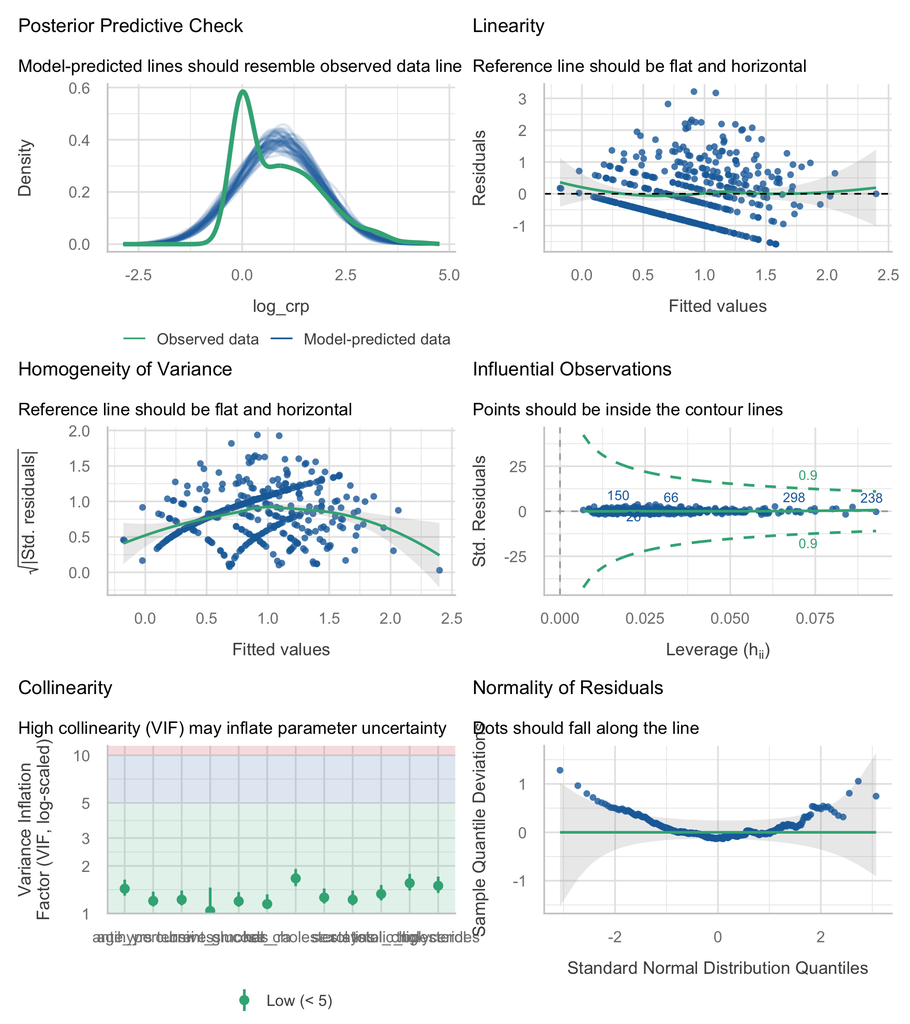

| Term | VIF | VIF_CI_low | VIF_CI_high | SE_factor | Tolerance | Tolerance_CI_low | Tolerance_CI_high |
| --- | --- | --- | --- | --- | --- | --- | --- |
| age_yrs | 1.434951 | 1.296967 | 1.637048 | 1.197894 | 0.6968879 | 0.6108556 | 0.7710296 |
| sex | 1.262435 | 1.156685 | 1.439559 | 1.123581 | 0.7921198 | 0.6946571 | 0.8645397 |
| has_ra | 1.148524 | 1.068413 | 1.322443 | 1.071692 | 0.8706828 | 0.7561761 | 0.9359675 |
| bmi | 1.223424 | 1.125744 | 1.396985 | 1.106085 | 0.8173778 | 0.7158272 | 0.8883015 |
| systolic_bp | 1.329540 | 1.210778 | 1.515218 | 1.153057 | 0.7521399 | 0.6599711 | 0.8259152 |
| current_smoker | 1.038635 | 1.003251 | 1.459078 | 1.019135 | 0.9628020 | 0.6853641 | 0.9967591 |
| statins | 1.223475 | 1.125783 | 1.397039 | 1.106108 | 0.8173443 | 0.7157997 | 0.8882704 |
| antihypertensives | 1.201808 | 1.108846 | 1.374165 | 1.096270 | 0.8320798 | 0.7277145 | 0.9018385 |
| total_cholesterol | 1.557098 | 1.397770 | 1.780244 | 1.247837 | 0.6422203 | 0.5617206 | 0.7154250 |
| hdl_cholesterol | 1.667614 | 1.489420 | 1.910688 | 1.291361 | 0.5996591 | 0.5233717 | 0.6714024 |

[output cut: 2 more lines]

**Table 3. Untransformed versus log-transformed outcome.**

| Outcome | Outcome skewness | Residual skewness | Shapiro-Wilk p | R-squared |
| --- | --- | --- | --- | --- |
| CRP (untransformed) | 5.07 | 5.01 | 2.8e-31 | 0.098 |
| log CRP | 0.87 | 0.77 | 2.1e-09 | 0.192 |

**Table 4. HC3 heteroscedasticity-consistent standard errors, on the ratio scale.**

| Term | Ratio | SE (OLS) | SE (HC3) | 95% CI (HC3), ratio scale | p (HC3) |
| --- | --- | --- | --- | --- | --- |
| age_yrs | 1.002 | 0.004 | 0.004 | 0.994 to 1.011 | 0.581 |
| sexMale | 0.789 | 0.096 | 0.107 | 0.639 to 0.974 | 0.027 |
| has_raRA | 1.538 | 0.091 | 0.085 | 1.302 to 1.817 | 0.000 |
| bmi | 1.036 | 0.010 | 0.011 | 1.014 to 1.058 | 0.001 |
| systolic_bp | 1.007 | 0.003 | 0.003 | 1.001 to 1.012 | 0.014 |
| current_smokerYes | 1.054 | 0.107 | 0.103 | 0.861 to 1.291 | 0.608 |
| statinsYes | 0.686 | 0.169 | 0.177 | 0.485 to 0.971 | 0.033 |
| antihypertensivesYes | 0.878 | 0.115 | 0.124 | 0.688 to 1.120 | 0.295 |
| total_cholesterol | 0.857 | 0.046 | 0.047 | 0.782 to 0.939 | 0.001 |
| hdl_cholesterol | 0.845 | 0.112 | 0.137 | 0.645 to 1.106 | 0.220 |
| triglycerides | 1.149 | 0.071 | 0.075 | 0.991 to 1.332 | 0.065 |
| glucose | 1.102 | 0.062 | 0.060 | 0.980 to 1.241 | 0.106 |

**The transformation was the right call, and Table 3 is the evidence.** Residual skewness drops from 5.01 on the raw scale to 0.77 after logging, the Shapiro-Wilk p-value improves by more than twenty orders of magnitude, and R-squared rises from 0.098 to 0.192. On the raw scale the residual-versus-fitted plot is a wedge dominated by a dozen participants with CRP above 20; on the log scale it is broadly flat.

**Collinearity is not a problem.** The largest variance inflation factor is 1.67, for hdl_cholesterol, and every VIF is below 2 - well short of the conventional threshold of 5. That follows directly from the exclusions in Methods; the same model with `ldl_cholesterol`, `waist_cm` and `diastolic_bp` added has lipid VIFs of about 501.

**No influential observations.** The largest Cook’s distance is 0.040 and the largest leverage 0.093, so no single participant drives the fit - another benefit of the log scale, since on the raw scale the participant with CRP 71 is enormously influential.

# Discussion

In this Dutch case-control sample, C-reactive protein is raised most clearly by rheumatoid arthritis and by adiposity. RA cases have 1.538 (95% CI 1.285 to 1.841) times the geometric mean CRP of controls of the same age, sex, body mass, blood pressure and lipid profile, and each 5 kg/m2 of BMI multiplies CRP by about 1.19. Systolic blood pressure and total cholesterol contribute smaller independent associations, and men have about 21% lower CRP than women once lipids are held constant. Practically, the finding that matters is that a substantial part of the raised CRP in RA patients is not the arthritis: adjustment for conventional cardiovascular risk factors removes about 31% of the crude excess, most of it attributable to body mass and blood pressure. Clinicians reading a raised CRP in an RA patient as evidence of active joint disease should note how much of it adiposity can explain.

The statin coefficient is the one that must not be over-read. Taken at face value, the statin ratio of 0.686 (95% CI 0.493 to 0.956) says statin users have around 31% lower CRP, and there is a real pharmacological literature reporting exactly that. But statins in this dataset are **confounded by indication in both directions at once**. People are prescribed statins because their lipids and cardiovascular risk are poor: users here are on average 5.6 years older and, despite treatment, still have total cholesterol of 4.7 mmol/L against 5.5 in non-users - that pushes their apparent CRP up. At the same time, statin use is concentrated in the control group (13.9% of controls versus 4.4% of RA cases), and controls have much lower CRP for reasons that have nothing to do with statins - that pushes it down. The adjusted coefficient additionally conditions on total cholesterol and HDL, which are the very quantities statins are given to change, so it is adjusting for a mediator. The same logic applies to `antihypertensives`. Neither column of Table 2 is a treatment effect, and a randomised comparison is the only thing that would be.

**Limitations.** The design is cross-sectional, so nothing here establishes temporal order; in particular the BMI-CRP association is bidirectional in principle, though the adipose-tissue mechanism makes the BMI-to-CRP direction the more plausible one. **CRP is left-censored**: 42% of participants sit at the reporting limit of 1, and the linear model treats these as exact values, which biases coefficients toward the null and is the direct cause of the failed normality and variance checks. CRP is also an *acute-phase* reactant, so a single measurement partly reflects incidental infection at the time of sampling rather than chronic inflammatory burden; that is non-differential noise which will attenuate all associations. RA disease activity, disease duration and disease-modifying treatment - the variables that actually determine CRP within the RA group - are **not in this extract at all**, being undefined for the 163 controls, so the RA coefficient is an average across patients whose disease may be quiescent or raging. `prednisone`, an anti-inflammatory that directly suppresses CRP, was excluded as a pathway variable, so its effect is folded into the RA coefficient. Statins and antihypertensives are confounded by indication as described above. Complete-case analysis dropped 15 of 470 rows. The sample is a single Dutch centre. All estimates are associations, not causal effects.

**Future work.** Refit as a censored-normal (tobit) model with the reporting limit at 1, and, within the RA cases only, replace the RA indicator with DAS28 disease activity from the full deposit to test whether CRP tracks disease activity or simply the RA label.

# Feasibility notes

*NOT part of a student report.*

- **USABLE WITH WARNINGS.** 455 complete cases, R-squared 0.192 on the log scale, a strong and substantively sensible signal (RA status and BMI), and no collinearity or influence problems. The warnings are about the outcome’s distribution, not about the model.
- **FATAL if untransformed.** Raw CRP has skewness 5.1 and runs from 1 to 71. The untransformed model has residual skewness 5.01, R-squared 0.098 (against 0.192 logged), and is dominated by a dozen participants in an acute-phase response. A student who reports untransformed CRP has an uninterpretable model, not merely an assumption violation. **The catalogue’s “consider log-transforming” note should be firmed up to “log-transform”.**
- **MAJOR: CRP is left-censored at the reporting limit.** 42% of the analytic sample has CRP exactly 1, which is “below the assay threshold” rather than a measured value. This point mass is why `check_normality()` and `check_heteroscedasticity()` still reject **after** logging, and it is not fixable by transformation. Students will report failed diagnostics no matter what they do; the correct answer is to name the censoring and move on (or fit a tobit model, which is beyond the course). This should be in the caution list.
- **MAJOR: `crp` is in `meta.json`’s suggested predictor list** and must be dropped when CRP is the outcome. A student who leaves it in gets R-squared = 1. This is the one genuinely circular pairing in the dataset.
- **MAJOR trap: `ldl_cholesterol` is the Friedewald calculation, not a measurement** (correlation 0.9987 with `total - HDL - triglycerides/2.2`). Including it with all three inputs sends the lipid VIFs into the hundreds.
- **MAJOR interpretive trap: `statins` and `antihypertensives` are confounded by indication**, and here the confounding is doubly awkward because statin use is concentrated in the *control* group (13.9% of controls versus 4.4% of RA cases). The statin coefficient crosses into significance on adjustment (0.798 (95% CI 0.575 to 1.108) to 0.686 (95% CI 0.493 to 0.956)) and looks like a beautiful anti-inflammatory effect. It is not evidence of one.
- **MINOR: `prednisone` sits on the causal pathway.** It is an anti-inflammatory given almost exclusively to RA patients (1 of 39 users are controls). Adding it to a model with `has_ra` is adjusting for a mediator and shrinks the RA coefficient for the wrong reason.
- **MINOR: redundant pairs.** `bmi`/`waist_cm` (r 0.81), `systolic_bp`/`diastolic_bp` (r 0.67), `apo_a`/`hdl_cholesterol` (r 0.55), `apo_b`/`total_cholesterol` (r 0.83). With the chosen subset the maximum VIF is 1.67.
- **MINOR: the units of `crp` are not documented.** The codebook says only “C-reactive protein (inflammatory marker)”. The integer-valued 1-71 range is consistent with mg/L but nothing in the deposit confirms it, so students cannot compare their numbers with published reference ranges with any confidence.
- **MINOR: CRP is an acute-phase reactant measured once.** Incidental infection at the time of sampling is measurement error that will attenuate every association; there is no way to detect or adjust for it here.
- **MINOR data defect: row `id = "control_row1"` is entirely blank.**
- **Verified clean:** `sex` ships as female/male and `height_cm` as 145-206 cm with 0 values in metres, so both documented Zenodo defects are fixed in this catalogue’s CSV. No RA-specific columns are present.